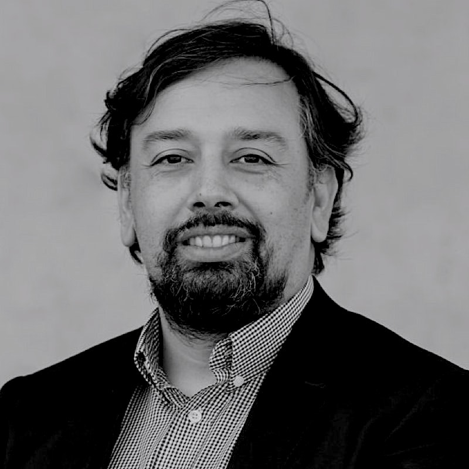

# Mauricio Apablaza

I am director of research at the School of Government at the Universidad del Desarrollo, Chile and academic director of the programme Conocimiento e Investigación en Personas Mayores (CIPEM). I am alse research associate at Oxford University (OPHI), research fellow at the London School of Economics (LSE-III) and Universidad de Chile (CSP). Previously, I worked as a Research Officer and Outreach Coordinator at OPHI, where I led training programmes for OPHI in South Africa, Malaysia, Indonesia, Jordan, Egypt, Hungary, Brasil, Chile, the Netherlands, Barbados, US, Vietnam, Nicaragua and Thailand, among others. I have published articles in PLOS ONE, World Development, Journal of Ethnic and Migration Studies, and the Review of Income and Wealth, among others. I teach applied microeconomics and quantitative methods at the undergraduate and graduate level (Masters and PhD) at the Universidad del Desarrollo. I hold a PhD in Economics from the University of Nottingham. His research areas and publications focus on institutions, multidimensional indicators and labour market dynamics.